# Data Practices 2026 — Assignment 02

## 3.5 ✏️ Exercise 5 — Multi-step Pipeline with Visualisation: The Health-Wealth Relationship

**Topic:** Does money buy health? The Preston Curve

The **Preston Curve** is one of the most replicated findings in demography: richer countries tend to have higher life expectancy, but the relationship is concave (diminishing returns). Your task is to reproduce a version of this classic chart.

**Your task:**

1. Take the 2019 data (before pandemic disruptions).
2. Keep only countries with non-missing values for both `gdp_per_capita` and `life_expectancy`.
3. Remove countries with population under 1 million (small island states distort the picture).
4. Create a scatter plot with **log-scaled GDP per capita** on the x-axis and **life expectancy** on the y-axis. Colour the points by `income` group. Add a smooth trend line (not broken by group). Label at minimum the five richest and five poorest countries by name using `geom_text()` or `ggrepel`.
5. Add informative axis labels, a title, and a caption citing the data source.

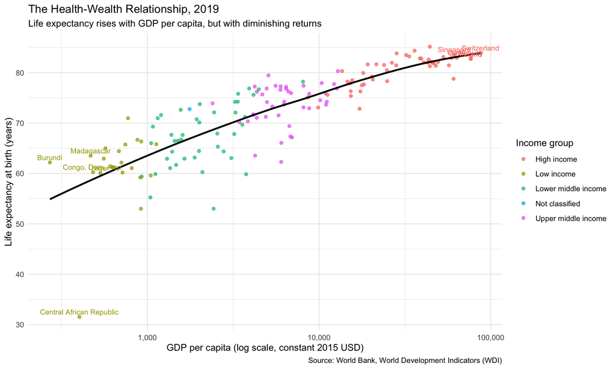

```r
# ✏️ Write your solution here

data_2019 <- wdi |>
  filter(
    year == 2019,
    !is.na(gdp_per_capita),
    !is.na(life_expectancy),
    population >= 1e6
  )

label_data <- bind_rows(
  data_2019 |> slice_max(gdp_per_capita, n = 5),
  data_2019 |> slice_min(gdp_per_capita, n = 5)
)

ggplot(data_2019, aes(x = gdp_per_capita, y = life_expectancy, colour = income)) +
  geom_point(alpha = 0.7) +
  geom_smooth(aes(group = 1), method = "loess", se = FALSE, colour = "black") +
  geom_text(
    data = label_data,
    aes(label = country_name),
    size = 3,
    vjust = -0.5,
    show.legend = FALSE
  ) +
  scale_x_log10(labels = scales::label_comma()) +
  labs(
    title = "The Health-Wealth Relationship, 2019",
    subtitle = "Life expectancy rises with GDP per capita, but with diminishing returns",
    x = "GDP per capita (log scale, constant 2015 USD)",
    y = "Life expectancy at birth (years)",
    colour = "Income group",
    caption = "Source: World Bank, World Development Indicators (WDI)"
  ) +
  theme_minimal()
```

**Tip💡 Hint 1 — Where to start**

This is a full pipeline: filter → mutate (optional log transform) → plot. For the scatter plot, `ggplot2` handles this naturally with `geom_point()`. The log scale can be applied with `scale_x_log10()` rather than transforming the variable itself. For country labels, look at the `ggrepel` package (`geom_text_repel()`), which avoids overlapping labels — install it if needed.

**Tip💡 Hint 2 — More detail**

Basic scatter plot structure with a log x-axis and a smooth line:

```r
# Example structure
ggplot(data, aes(x = some_variable, y = other_variable, colour = group)) +
  geom_point(alpha = 0.7) +
  geom_smooth(aes(group = 1), method = "loess", colour = "grey30", se = FALSE) +
  scale_x_log10(labels = scales::label_comma()) +
  scale_colour_viridis_d(option = "plasma") +
  labs(title = "...", x = "...", y = "...", caption = "Source: World Bank WDI")
```

To label only extreme countries, create a separate `label_data` object filtered to `slice_max(gdp_per_capita, n=5)` and `slice_min(gdp_per_capita, n=5)`, then add `geom_text(data = label_data, aes(label = country_name))`.

# 4 Part 2 — Weighted Survey Analysis with Pew 2024

In this section you will work with the **Pew Research Center Global Attitudes Spring 2024** survey. All estimates must use the survey weight variable to be nationally representative. We use the `srvyr` package, which brings familiar tidyverse syntax to weighted survey analysis.

**Important⚖️ Why weights are not optional**

The Pew sample is not a simple random sample. Some groups (e.g. younger adults, minority language speakers) are deliberately over- or under-sampled to ensure enough cases for subgroup analysis, and to compensate for differential non-response rates. The `weight` variable corrects for this so that your estimates represent the **national adult population**, not the people who happened to respond.

Running `mean(pew$dem_satisfied, na.rm = TRUE)` would give you the *sample* proportion — which can be several percentage points away from the nationally representative estimate. Always use `pew_design` with `srvyr` functions.

```r
# Correct — weighted
pew_design |> summarise(survey_mean(dem_satisfied, na.rm = TRUE))

# Wrong for inference — unweighted
pew |> summarise(mean(dem_satisfied, na.rm = TRUE))
```

## 4.1 ✏️ Exercise 6 — Weighted Frequencies: Democracy Satisfaction by Country

**Topic:** How satisfied are people with democracy?

**Your task:** For each country in the dataset, calculate the **weighted percentage of respondents who are satisfied with democracy** (`dem_satisfied == 1`). Sort the results from highest to lowest satisfaction. Display as a clean table showing country, percentage satisfied, and the effective (unweighted) number of respondents per country.

```r
# ✏️ Write your solution here
pew_design |>
  group_by(country) |>
  summarise(
    pct_satisfied = survey_mean(dem_satisfied, na.rm = TRUE) * 100,
    n = unweighted(n())
  ) |>
  arrange(desc(pct_satisfied)) |>
  select(
    Country = country,
    `SAtisfied Rate` = pct_satisfied,
    `Respondents (n)` = n
  ) |>
  knitr::kable(digits = 1)
```

| Country | SAtisfied Rate | Respondents (n) |
| --- | --- | --- |
| Singapore | 80.8 | 1014 |
| India | 79.6 | 3559 |
| Sweden | 75.9 | 1017 |
| Thailand | 64.5 | 1000 |
| Australia | 60.3 | 2021 |
| Poland | 59.1 | 1031 |
| Netherlands | 58.7 | 1010 |
| Philippines | 57.5 | 1011 |
| Germany | 54.9 | 1008 |
| Canada | 53.3 | 1163 |
| Kenya | 52.7 | 1049 |
| Malaysia | 51.4 | 1005 |
| Mexico | 49.9 | 1042 |
| Hungary | 49.6 | 996 |
| Ghana | 48.5 | 1035 |
| Israel | 45.5 | 1001 |
| Brazil | 45.1 | 1054 |
| Argentina | 44.4 | 1017 |
| Sri Lanka | 39.9 | 2519 |
| UK | 39.4 | 1017 |
| South Korea | 36.4 | 1029 |
| France | 34.7 | 1018 |
| Turkey | 33.0 | 1049 |
| Italy | 32.4 | 1120 |
| Japan | 31.7 | 1003 |
| Chile | 31.2 | 1020 |
| Spain | 31.0 | 1013 |
| South Africa | 28.7 | 1524 |
| Greece | 22.3 | 1015 |
| Colombia | 21.4 | 1051 |
| Peru | 11.0 | 1050 |
| Bangladesh | 0.0 | 1046 |
| Indonesia | 0.0 | 937 |
| Nigeria | 0.0 | 1050 |
| Tunisia | 0.0 | 1009 |

**Tip💡 Hint 1 — Where to start**

You need to group the survey design object by country, then compute a weighted mean of a binary 0/1 variable. The weighted mean of a binary variable equals the weighted proportion of 1s. All `srvyr` summarise functions work inside `summarise()` just like regular `dplyr` — but use `survey_mean()` instead of `mean()`.

**Tip💡 Hint 2 — More detail**

```r
# Example: weighted % saying religion is important, by country
pew_design |>
  group_by(country) |>
  summarise(
    pct_religious = survey_mean(religion_important, na.rm = TRUE),
    n = unweighted(n())
  ) |>
  arrange(desc(pct_religious))
```

`survey_mean()` returns the proportion by default. Multiply by 100 for a percentage. `unweighted(n())` gives the actual number of survey respondents (not the weighted count).

## 4.2 ✏️ Exercise 7 — Weighted Crosstab: Press Freedom Importance by Age Group

**Topic:** Generational differences in attitudes toward press freedom

```r
# ✏️ Write your solution here
pew_design |>
  filter(!is.na(country), !is.na(age_group), !is.na(gender)) |>
  group_by(country, age_group, gender) |>
  summarise(
    pct_press_freedom = survey_mean(press_freedom_imp, na.rm = TRUE) * 100
  ) |>
  mutate(pct_press_freedom = round(pct_press_freedom, 1)) |>
  select(country, age_group, gender, pct_press_freedom) |>
  pivot_wider(
    names_from = gender,
    values_from = pct_press_freedom
  ) |>
  arrange(country, age_group) |>
  knitr::kable(
    col.names = c("Country", "Age group", "Female", "Male")
  )
```

| Country | Age group | Female | Male |
| --- | --- | --- | --- |
| Argentina | 18–29 | 93.2 | 93.6 |
| Argentina | 30–49 | 95.5 | 93.1 |
| Argentina | 50–64 | 91.9 | 95.9 |
| Argentina | 65+ | 85.3 | 82.3 |
| Bangladesh | 18–29 | 83.1 | 76.0 |
| Bangladesh | 30–49 | 81.6 | 83.2 |
| Bangladesh | 50–64 | 81.0 | 85.5 |
| Bangladesh | 65+ | 62.2 | 76.5 |
| Brazil | 18–29 | 80.4 | 86.2 |
| Brazil | 30–49 | 81.2 | 85.1 |
| Brazil | 50–64 | 79.5 | 81.5 |
| Brazil | 65+ | 76.2 | 75.8 |
| Canada | 18–29 | 95.2 | 90.3 |
| Canada | 30–49 | 95.7 | 94.8 |
| Canada | 50–64 | 94.5 | 96.1 |
| Canada | 65+ | 96.8 | 91.2 |
| Chile | 18–29 | 94.7 | 93.6 |
| Chile | 30–49 | 89.1 | 96.6 |
| Chile | 50–64 | 93.3 | 88.8 |
| Chile | 65+ | 88.6 | 86.5 |
| Colombia | 18–29 | 82.5 | 80.0 |
| Colombia | 30–49 | 86.2 | 85.5 |
| Colombia | 50–64 | 74.7 | 76.2 |
| Colombia | 65+ | 72.6 | 70.4 |
| France | 18–29 | 94.7 | 90.9 |
| France | 30–49 | 94.0 | 85.1 |
| France | 50–64 | 92.0 | 91.0 |
| France | 65+ | 86.1 | 90.9 |
| Germany | 18–29 | 86.8 | 91.1 |
| Germany | 30–49 | 91.6 | 85.6 |

[output cut: 106 more lines]

**Tip💡 Hint 1 — Where to start**

This is a two-way breakdown: group by two variables simultaneously and compute a weighted proportion. The result will be in long format — think about how to pivot it into a wide crosstab with one column per gender. Look at `pivot_wider()` for reshaping.

**Tip💡 Hint 2 — More detail**

```r
# Example: weighted proportions by two grouping variables, then pivot wide
pew_design |>
  filter(!is.na(age_group), !is.na(gender)) |>
  group_by(age_group, gender) |>
  summarise(pct = survey_mean(econ_good, na.rm = TRUE)) |>
  select(age_group, gender, pct) |>
  pivot_wider(names_from = gender, values_from = pct)
```

Multiply `pct` by 100 and round to 1 decimal before pivoting for a cleaner table. You can pass the result to `knitr::kable()` for nice formatting.

## 4.3 ✏️ Exercise 8 — Comparing Weighted Means: Economic Optimism Across Income Levels

**Topic:** Does economic context shape personal economic sentiment?

**Your task:**

1. Join the Pew data with the WDI 2023 GDP per capita figures (match on country name — you will need to handle some name mismatches manually or use `stringr` to clean them).
2. Create a variable `gdp_group` that splits countries into three roughly equal groups by GDP per capita: Low, Middle, High (use `ntile()` or manual cut-points).
3. Compute the **weighted percentage reporting a good personal economic situation** (`econ_good == 1`) by `gdp_group`.
4. Visualise the result as a simple bar chart with error bars (use the standard error returned by `survey_mean()`).

```r
# ✏️ Write your solution here


#1
wdi_2023 <- WDI(
  indicator = "NY.GDP.PCAP.KD",
  start = 2023,
  end = 2023,
  extra = TRUE
) |>
  rename(
    country_name = country,
    gdp_per_capita = NY.GDP.PCAP.KD
  ) |>
  filter(region != "Aggregates", !is.na(region), !is.na(gdp_per_capita)) |>
  select(country_name, gdp_per_capita)

#2
pew_joined <- pew |>
  mutate(
    country_join = recode(
      country,
      "US" = "United States",
      "South Korea" = "Korea, Rep.",
      "Ivory Coast" = "Cote d'Ivoire",
      "Czech Republic" = "Czechia",
      "Russia" = "Russian Federation",
      "Turkey" = "Turkiye",
      .default = country
    )
  ) |>
  left_join(wdi_2023, by = c("country_join" = "country_name"))


pew_joined |>
  filter(is.na(gdp_per_capita)) |>
  distinct(country)
```

| country |
| --- |
| UK |

```r
# 3
country_gdp_groups <- pew_joined |>
  distinct(country, gdp_per_capita) |>
  filter(!is.na(gdp_per_capita)) |>
  mutate(
    gdp_group = ntile(gdp_per_capita, 3),
    gdp_group = case_when(
      gdp_group == 1 ~ "Low",
      gdp_group == 2 ~ "Middle",
      gdp_group == 3 ~ "High"
    )
  )

# 4
pew_with_gdp <- pew_joined |>
  left_join(country_gdp_groups, by = c("country", "gdp_per_capita"))

# 5
pew_design_gdp <- pew_with_gdp |>
  as_survey_design(weights = weight)

# 6
econ_by_gdp <- pew_design_gdp |>
  filter(!is.na(gdp_group)) |>
  group_by(gdp_group) |>
  summarise(
    result = survey_mean(econ_good, na.rm = TRUE, vartype = "se")
  ) |>
  mutate(
    pct = result * 100,
    se_pct = result_se * 100,
    lower = pct - 1.96 * se_pct,
    upper = pct + 1.96 * se_pct
  )

# 7. Table
econ_by_gdp |>
  select(
    `GDP group` = gdp_group,
    `Percent saying economy is good` = pct,
    `SE` = se_pct
  ) |>
  knitr::kable(digits = 1)
```

| GDP group | Percent saying economy is good | SE |
| --- | --- | --- |
| High | 39.5 | 0.6 |
| Low | 42.8 | 0.5 |
| Middle | 37.1 | 0.6 |

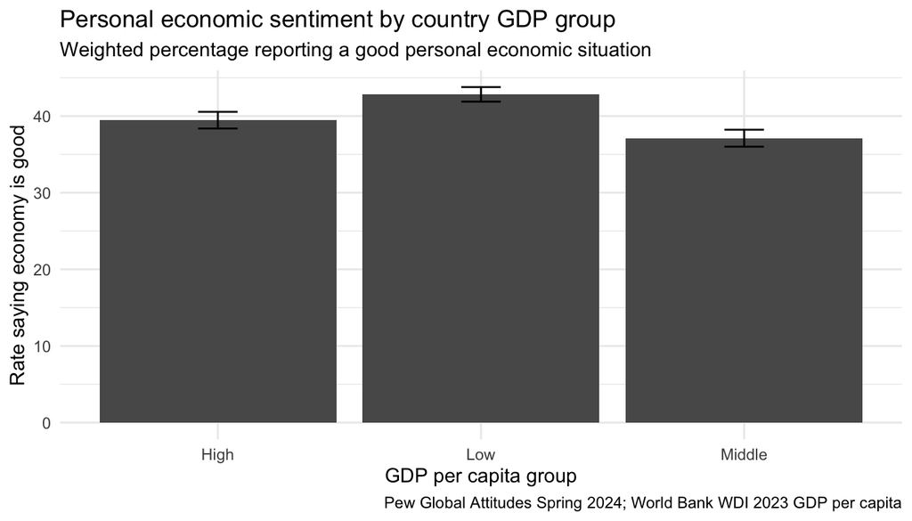

```r
# 8. Bar chart +
ggplot(econ_by_gdp, aes(x = gdp_group, y = pct)) +
  geom_col() +
  geom_errorbar(aes(ymin = lower, ymax = upper), width = 0.15) +
  labs(
    title = "Personal economic sentiment by country GDP group",
    subtitle = "Weighted percentage reporting a good personal economic situation",
    x = "GDP per capita group",
    y = "Rate saying economy is good",
    caption = "Pew Global Attitudes Spring 2024; World Bank WDI 2023 GDP per capita"
  ) +
  theme_minimal()
```

**Tip💡 Hint 1 — Where to start**

This requires a join between two datasets. The challenge is that country names in Pew may not exactly match those in WDI (e.g. “United States” vs “United States of America”). Think about which join function to use, and how to check which countries failed to match. For the visualisation, `geom_col()` with `geom_errorbar()` is the standard approach for bar charts with confidence intervals.

**Tip💡 Hint 2 — More detail**

```r
# Get WDI country names for a specific year
wdi_2022 <- wdi |>
  filter(year == 2022, !is.na(gdp_per_capita)) |>
  select(country_name, gdp_per_capita)

# Left join — rows in pew without a match get NA
pew_joined <- pew |>
  left_join(wdi_2022, by = c("country" = "country_name"))

# Check which countries didn't match
pew_joined |> filter(is.na(gdp_per_capita)) |> distinct(country)
```

For the error bars, `survey_mean()` returns both `_mean` and `_se` columns when you name the output:

```r
pew_design |>
  group_by(gdp_group) |>
  summarise(result = survey_mean(econ_good, na.rm = TRUE, vartype = "se"))
# This gives result (the mean) and result_se (the standard error)
```

Use `geom_errorbar(aes(ymin = result - 1.96*result_se, ymax = result + 1.96*result_se))`.

## 4.4 ✏️ Exercise 9 — Weighted Subgroup Analysis: Religion and Economic Views

**Topic:** Does religiosity correlate with economic optimism?

**Your task:** Among European countries only (select at least 5 countries from the Pew data that are clearly European), test whether **religiously important respondents** differ from **non-religious respondents** in their assessment of the **personal economic situation** (`econ_good`). Compute the weighted proportions for each religious group separately **per country**, then visualise the comparison as a **grouped bar chart** or a **dot plot with connecting lines** (one dot per country, connected across religious groups). Write a short interpretation.

```r
# ✏️ Write your solution here

result <- pew_design |>
  filter(
    country %in% c("Germany", "Slovakia", "Monaco", "Sweden", "Spain", "Hungary"),
    !is.na(religion_important),
    !is.na(econ_good)
  ) |>
  group_by(country, religion_important) |>
  summarise(
    pct = survey_mean(econ_good, na.rm = TRUE)
  ) |>
  mutate(
    pct = pct * 100,
    religious_label = ifelse(
      religion_important == 1,
      "Religion important",
      "Religion not important"
    )
  )

result |>
  knitr::kable(digits = 1)
```

| country | religion_important | pct | pct_se | religious_label |
| --- | --- | --- | --- | --- |
| Germany | 0 | 39.1 | 0 | Religion not important |
| Germany | 1 | 39.6 | 0 | Religion important |
| Hungary | 0 | 33.5 | 0 | Religion not important |
| Hungary | 1 | 52.0 | 0 | Religion important |
| Spain | 0 | 37.8 | 0 | Religion not important |
| Spain | 1 | 36.1 | 0 | Religion important |
| Sweden | 0 | 51.0 | 0 | Religion not important |
| Sweden | 1 | 57.5 | 0 | Religion important |

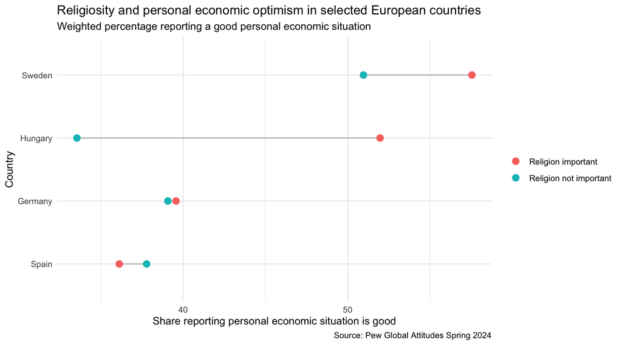

```r
ggplot(
  result,
  aes(
    x = pct,
    y = reorder(country, pct),
    colour = religious_label
  )
) +
  geom_line(aes(group = country), colour = "grey70") +
  geom_point(size = 3) +
  labs(
    title = "Religiosity and personal economic optimism in selected European countries",
    subtitle = "Weighted percentage reporting a good personal economic situation",
    x = "Share reporting personal economic situation is good",
    y = "Country",
    colour = NULL,
    caption = "Source: Pew Global Attitudes Spring 2024"
  ) +
  theme_minimal()
```

**Tip💡 Hint 1 — Where to start**

Filter `pew_design` to European countries first using `filter(country %in% c(...))`. Then group by two variables: country and religiosity. Compute the weighted proportion of `econ_good` for each combination. A dot plot with lines connecting the two religiosity dots within each country is effective — think about `geom_point()` and `geom_line()`, with country on one axis and proportion on the other.

**Tip💡 Hint 2 — More detail**

```r
# Compute weighted proportions by two grouping variables
result <- pew_design |>
  filter(country %in% c("Germany", "France", "Poland",
                         "Sweden", "Spain", "Hungary"),
         !is.na(religion_important), !is.na(econ_good)) |>
  group_by(country, religion_important) |>
  summarise(pct = survey_mean(econ_good, na.rm = TRUE)) |>
  mutate(religious_label = ifelse(religion_important == 1,
                                  "Religion important", "Not important"))
```

For the connected dot plot:

```r
ggplot(result, aes(x = pct, y = reorder(country, pct),
                   colour = religious_label)) +
  geom_line(aes(group = country), colour = "grey70") +
  geom_point(size = 4) +
  scale_x_continuous(labels = scales::percent) +
  labs(colour = NULL)
```

## 4.5 ✏️ Exercise 10 — Advanced: A Country Ranking Dashboard

**Topic:** Building a multi-indicator summary

**Your task:** Produce a single summary table that ranks all Pew countries by **four weighted indicators simultaneously**:

1. `dem_satisfied` — % satisfied with democracy
2. `press_freedom_imp` — % valuing press freedom
3. `econ_good` — % with positive economic outlook
4. `religion_important` — % for whom religion is important

For each indicator, compute the weighted national proportion. Then add a `composite_score` column defined as the **mean of the first three indicators** (democracy satisfaction + press freedom + economic optimism) — treating this as a rough “liberal-democratic optimism index”. Sort by `composite_score` descending.

Finally, visualise the result as a **heatmap** where rows are countries, columns are the four indicators, and the fill colour encodes the weighted percentage. Use a diverging colour scale centred at 50%.

```r
# ✏️ Write your solution here

summary_table <- pew_design |>
  group_by(country) |>
  summarise(
    dem_sat   = survey_mean(dem_satisfied, na.rm = TRUE),
    press_fr  = survey_mean(press_freedom_imp, na.rm = TRUE),
    econ_opt  = survey_mean(econ_good, na.rm = TRUE),
    religious = survey_mean(religion_important, na.rm = TRUE)
  ) |>
  mutate(
    composite_score = (dem_sat + press_fr + econ_opt) / 3
  ) |>
  mutate(
    dem_sat = round(dem_sat * 100, 1),
    press_fr = round(press_fr * 100, 1),
    econ_opt = round(econ_opt * 100, 1),
    religious = round(religious * 100, 1),
    composite_score = round(composite_score * 100, 1)
  ) |>
  arrange(desc(composite_score))

summary_table |>
  select(
    Country = country,
    `Democracy satisfied (%)` = dem_sat,
    `Press freedom important (%)` = press_fr,
    `Economic optimism (%)` = econ_opt,
    `Religion important (%)` = religious,
    `Composite score (%)` = composite_score
  ) |>
  knitr::kable()
```

| Country | Democracy satisfied (%) | Press freedom important (%) | Economic optimism (%) | Religion important (%) | Composite score (%) |
| --- | --- | --- | --- | --- | --- |
| Singapore | 80.8 | 85.7 | 76.8 | 72.7 | 81.1 |
| India | 79.6 | 80.5 | 79.0 | 95.5 | 79.7 |
| Sweden | 75.9 | 97.8 | 52.5 | 20.5 | 75.4 |
| Netherlands | 58.7 | 92.6 | 65.6 | 36.9 | 72.3 |
| Philippines | 57.5 | 85.8 | 66.6 | 96.0 | 70.0 |
| Poland | 59.1 | 93.2 | 55.1 | 67.5 | 69.1 |
| Mexico | 49.9 | 85.7 | 63.7 | 75.8 | 66.4 |
| Thailand | 64.5 | 88.5 | 37.5 | 92.4 | 63.5 |
| Australia | 60.3 | 92.5 | 37.4 | 30.9 | 63.4 |
| Malaysia | 51.4 | 81.1 | 54.5 | 93.8 | 62.4 |
| Germany | 54.9 | 91.7 | 39.1 | 36.0 | 61.9 |
| Hungary | 49.6 | 92.6 | 41.6 | 43.3 | 61.2 |
| Canada | 53.3 | 94.5 | 34.3 | 48.6 | 60.7 |
| Israel | 45.5 | 77.6 | 45.4 | 60.5 | 56.2 |
| Brazil | 45.1 | 81.6 | 38.4 | 88.8 | 55.0 |
| Spain | 31.0 | 93.1 | 37.2 | 40.1 | 53.7 |
| Sri Lanka | 39.9 | 87.7 | 27.7 | 98.7 | 51.8 |
| UK | 39.4 | 94.0 | 21.7 | 43.8 | 51.7 |
| Chile | 31.2 | 91.8 | 31.7 | 64.0 | 51.6 |
| Kenya | 52.7 | 64.5 | 35.9 | 97.3 | 51.1 |
| France | 34.7 | 90.1 | 24.5 | 37.4 | 49.8 |
| Argentina | 44.4 | 92.3 | 11.9 | 59.1 | 49.5 |
| Ghana | 48.5 | 83.9 | 16.1 | 92.6 | 49.5 |
| Bangladesh | 0.0 | 81.0 | 67.3 | 99.7 | 49.4 |
| Italy | 32.4 | 89.4 | 23.8 | 56.2 | 48.5 |
| Greece | 22.3 | 96.8 | 24.1 | 62.2 | 47.7 |
| Japan | 31.7 | 87.7 | 23.0 | 29.1 | 47.5 |
| Turkey | 33.0 | 91.7 | 16.6 | 87.9 | 47.1 |
| South Korea | 36.4 | 88.6 | 16.1 | 43.4 | 47.0 |
| Indonesia | 0.0 | 84.8 | 53.9 | 99.7 | 46.2 |
| Colombia | 21.4 | 80.4 | 34.5 | 84.2 | 45.4 |
| South Africa | 28.7 | 72.5 | 27.6 | 88.5 | 43.0 |
| Peru | 11.0 | 78.6 | 26.3 | 85.2 | 38.6 |
| Nigeria | 0.0 | 76.0 | 10.7 | 95.9 | 28.9 |
| Tunisia | 0.0 | 0.0 | 14.0 | 99.3 | 4.7 |

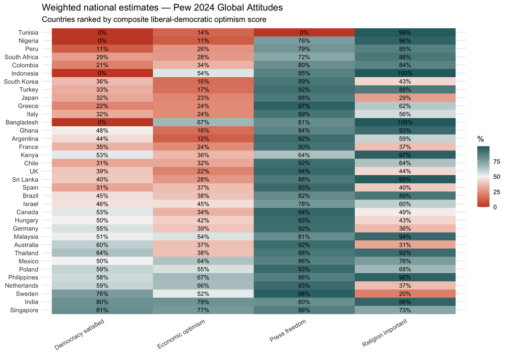

```r
summary_long <- summary_table |>
  select(country, dem_sat, press_fr, econ_opt, religious) |>
  pivot_longer(
    cols = -country,
    names_to = "indicator",
    values_to = "pct"
  ) |>
  mutate(
    indicator = recode(
      indicator,
      dem_sat = "Democracy satisfied",
      press_fr = "Press freedom",
      econ_opt = "Economic optimism",
      religious = "Religion important"
    ),
    country = factor(country, levels = summary_table$country)
  )

ggplot(summary_long, aes(x = indicator, y = country, fill = pct)) +
  geom_tile() +
  geom_text(aes(label = paste0(round(pct, 0), "%")), size = 3) +
  scale_fill_gradient2(
    low = "#c84b2f",
    mid = "#f5f5f5",
    high = "#2a6b6e",
    midpoint = 50
  ) +
  labs(
    title = "Weighted national estimates — Pew 2024 Global Attitudes",
    subtitle = "Countries ranked by composite liberal-democratic optimism score",
    x = NULL,
    y = NULL,
    fill = "%"
  ) +
  theme_minimal() +
  theme(
    axis.text.x = element_text(angle = 30, hjust = 1)
  )
```

**Tip💡 Hint 1 — Where to start**

This requires four separate `summarise()` calls (one per indicator) or a clever `across()` trick. The cleanest approach is to compute each indicator in one `group_by(country) |> summarise(...)` call. Then reshape the result to long format for the heatmap using `pivot_longer()`. For `geom_tile()`, the fill aesthetic should be the weighted proportion, with a diverging palette.

**Tip💡 Hint 2 — More detail**

Computing multiple indicators in one `summarise()` call:

```r
summary_table <- pew_design |>
  group_by(country) |>
  summarise(
    dem_sat   = survey_mean(dem_satisfied,     na.rm = TRUE),
    press_fr  = survey_mean(press_freedom_imp, na.rm = TRUE),
    econ_opt  = survey_mean(econ_good,         na.rm = TRUE),
    religious = survey_mean(religion_important, na.rm = TRUE)
  ) |>
  # keep only the point estimates, drop SE columns
  select(country, dem_sat, press_fr, econ_opt, religious)
```

For the heatmap, pivot to long format first:

```r
summary_long <- summary_table |>
  pivot_longer(-country, names_to = "indicator", values_to = "pct")

ggplot(summary_long, aes(x = indicator, y = reorder(country, pct),
                          fill = pct * 100)) +
  geom_tile() +
  scale_fill_gradient2(low = "#c84b2f", mid = "#f5f5f5",
                        high = "#2a6b6e", midpoint = 50) +
  geom_text(aes(label = paste0(round(pct*100, 0), "%")),
            size = 3, colour = "grey20") +
  labs(fill = "%", x = NULL, y = NULL,
       title = "Weighted national estimates — Pew 2024 Global Attitudes") +
  theme_minimal()
```

# Submission Checklist

Before submitting, check each item:

- All 10 exercises have code in the ✏️ chunks
- The document renders to HTML without errors (`Render` button or Ctrl+Shift+K)
- Exercises 5, 8, 9, and 10 include a plot
- Exercises 7, 9, and 10 include a written interpretation (2–3 sentences)
- You are submitting the rendered **`.html`** file, not the `.qmd`
- Your name and student ID appear on the rendered document (add them to the `author:` field in the YAML header above)

*Data sources: World Bank World Development Indicators (CC-BY 4.0) · Pew Research Center Global Attitudes Spring 2024 Survey · Corvinus University of Budapest, Survey Analytics and Big Data, 2025/2026*